# P1-Statistical Learning

Carolina Torrente Vélez

2022-10-27

## INTRODUCTION

Before starting with the entire work, we are going to introduce the personal motivation where we explain why we have chosen the data set.

Nowadays, an estimated 34.2 million people have diabetes, 1 out of 3 adults is an excessive drinker, more and more people is having mental problems, we move and exercise less than ever and a percentage of the population can’t see a doctor when they need it because of the cost. We are dealing with a lot of problems that are decreasing our quality of life. Therefore, through this study, we want to analyse the possible relations between these facts lately mentioned which have been measured in a survey with another 17 different variables related with the main topic (Global Health).

During the different unsupervised analysis that we are going to make, we will describe all the variables but if you want to read a previous explanation go to: https://www.kaggle.com/datasets/alexteboul/diabetes-health-indicators-dataset (source where we obtained the data but we took only 1200 observations approx.)

Questions:

Which could be the subset of variables that indicate a better health for any individual?

After PCA is there any difference between having diabetes or not taking to account the groups where they belong?

Could the answers of the last 2 questions change if we create 2 new variables and apply Factor Analysis?

Are the subgroups created with clustering associated between them in terms of quality of life?

## I) Data preprocessing

[output not shown]

1. Dealing with missing values

```r
data = read.csv("diabetes.csv")
summary(data)
```

```
##   Diabetes_012        HighBP          HighChol        CholCheck
##  Min.   :0.0000   Min.   :0.0000   Min.   :0.0000   Min.   :0.0000
##  1st Qu.:0.0000   1st Qu.:0.0000   1st Qu.:0.0000   1st Qu.:1.0000
##  Median :0.0000   Median :1.0000   Median :1.0000   Median :1.0000
##  Mean   :0.6455   Mean   :0.6275   Mean   :0.5516   Mean   :0.9804
##  3rd Qu.:2.0000   3rd Qu.:1.0000   3rd Qu.:1.0000   3rd Qu.:1.0000
##  Max.   :2.0000   Max.   :1.0000   Max.   :1.0000   Max.   :1.0000
##
##       BMI            Smoker           Stroke        HeartDiseaseorAttack
##  Min.   :14.00   Min.   :0.0000   Min.   :0.00000   Min.   :0.0000
##  1st Qu.:25.00   1st Qu.:0.0000   1st Qu.:0.00000   1st Qu.:0.0000
##  Median :29.00   Median :0.0000   Median :0.00000   Median :0.0000
##  Mean   :29.91   Mean   :0.4781   Mean   :0.08764   Mean   :0.2496
##  3rd Qu.:33.00   3rd Qu.:1.0000   3rd Qu.:0.00000   3rd Qu.:0.0000
##  Max.   :79.00   Max.   :1.0000   Max.   :1.00000   Max.   :1.0000
##  NA's   :8
##   PhysActivity        Fruits          Veggies       HvyAlcoholConsump
##  Min.   :0.0000   Min.   :0.0000   Min.   :0.0000   Min.   :0.0000
##  1st Qu.:0.0000   1st Qu.:0.0000   1st Qu.:0.0000   1st Qu.:0.0000
##  Median :1.0000   Median :1.0000   Median :1.0000   Median :0.0000
##  Mean   :0.6111   Mean   :0.5501   Mean   :0.7089   Mean   :0.0313
##  3rd Qu.:1.0000   3rd Qu.:1.0000   3rd Qu.:1.0000   3rd Qu.:0.0000
##  Max.   :1.0000   Max.   :1.0000   Max.   :1.0000   Max.   :1.0000
##
##  AnyHealthcare     NoDocbcCost        GenHlth         MentHlth
##  Min.   :0.0000   Min.   :0.0000   Min.   :1.000   Min.   : 0.000
##  1st Qu.:1.0000   1st Qu.:0.0000   1st Qu.:2.000   1st Qu.: 0.000
##  Median :1.0000   Median :0.0000   Median :3.000   Median : 0.000
##  Mean   :0.9554   Mean   :0.1228   Mean   :3.043   Mean   : 4.669
##  3rd Qu.:1.0000   3rd Qu.:0.0000   3rd Qu.:4.000   3rd Qu.: 4.000
##  Max.   :1.0000   Max.   :1.0000   Max.   :5.000   Max.   :30.000
##                                                    NA's   :1
##     PhysHlth         DiffWalk           Sex              Age
##  Min.   : 0.000   Min.   :0.0000   Min.   :0.0000   Min.   : 1.00
##  1st Qu.: 0.000   1st Qu.:0.0000   1st Qu.:0.0000   1st Qu.: 8.00
##  Median : 0.000   Median :0.0000   Median :0.0000   Median : 9.50
##  Mean   : 7.543   Mean   :0.3552   Mean   :0.3619   Mean   : 9.16
##  3rd Qu.:12.750   3rd Qu.:1.0000   3rd Qu.:1.0000   3rd Qu.:11.00
##  Max.   :30.000   Max.   :1.0000   Max.   :1.0000   Max.   :13.00
##                                    NA's   :4
##    Education         Income
##  Min.   :1.000   Min.   :1.000
##  1st Qu.:4.000   1st Qu.:3.000
##  Median :5.000   Median :5.000
##  Mean   :4.689   Mean   :5.076
##  3rd Qu.:6.000   3rd Qu.:7.000
##  Max.   :6.000   Max.   :8.000
##
```

```r
anyNA(data)
```

```
## [1] TRUE
```

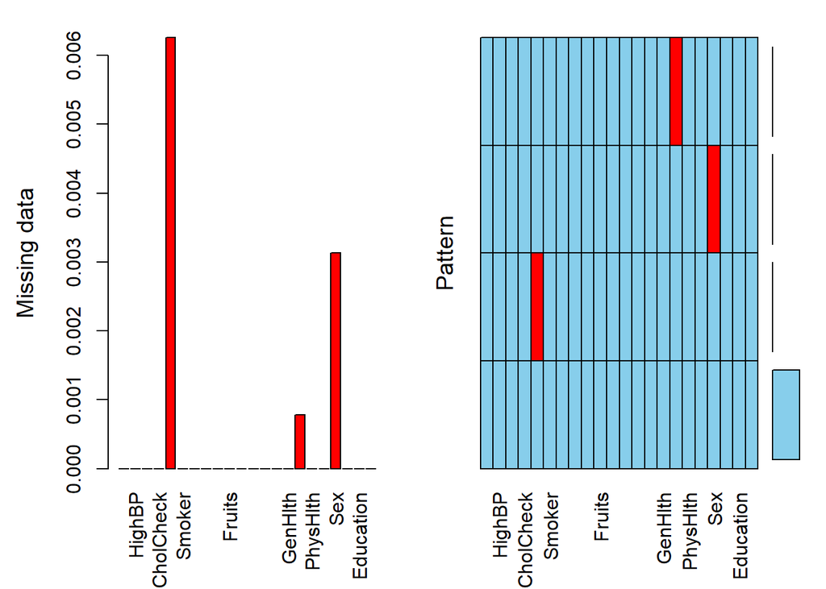

```r
aggr(data, plot=T, ylab= c('Missing data','Pattern'))
```

```r
# replace some NAs:
mean(data$BMI, na.rm = TRUE)
```

```
## [1] 29.91417
```

```r
data$BMI[is.na(data$BMI)]=mean(data$BMI,na.rm=TRUE)
data$MentHlth[is.na(data$MentHlth)]=mean(data$MentHlth,na.rm=TRUE)
data$Sex[is.na(data$Sex)]= 0

anyNA(data)
```

```
## [1] FALSE
```

2. Analysing the type of data

Now, we analyse the type of data. We transform into factors all categorical variables.

```r
data$Diabetes_012 = as.factor(data$Diabetes_012)
data$HighBP = as.factor(data$HighBP)
data$HighChol = as.factor(data$HighChol)
data$CholCheck= as.factor(data$CholCheck)
data$Smoker = as.factor(data$Smoker)
data$Stroke = as.factor(data$Stroke)
data$HeartDiseaseorAttack = as.factor(data$HeartDiseaseorAttack)
data$PhysActivity = as.factor(data$PhysActivity)
data$Fruits = as.factor(data$Fruits)
data$Veggies = as.factor(data$Veggies)
data$HvyAlcoholConsump = as.factor(data$HvyAlcoholConsump)
data$AnyHealthcare = as.factor(data$AnyHealthcare)
data$NoDocbcCost = as.factor(data$NoDocbcCost)
data$Sex = as.factor(data$Sex)
data$DiffWalk = as.factor(data$DiffWalk)
str(data)
```

```
## 'data.frame':    1278 obs. of  22 variables:
##  $ Diabetes_012        : Factor w/ 3 levels "0","1","2": 1 1 1 1 1 1 1 1 3 1 ...
##  $ HighBP              : Factor w/ 2 levels "0","1": 2 1 2 2 2 2 2 2 2 1 ...
##  $ HighChol            : Factor w/ 2 levels "0","1": 2 1 2 1 2 2 1 2 2 1 ...
##  $ CholCheck           : Factor w/ 2 levels "0","1": 2 1 2 2 2 2 2 2 2 2 ...
##  $ BMI                 : num  40 25 28 27 24 25 30 25 30 24 ...
##  $ Smoker              : Factor w/ 2 levels "0","1": 2 2 1 1 1 2 2 2 2 1 ...
##  $ Stroke              : Factor w/ 2 levels "0","1": 1 1 1 1 1 1 1 1 1 1 ...
##  $ HeartDiseaseorAttack: Factor w/ 2 levels "0","1": 1 1 1 1 1 1 1 1 2 1 ...
##  $ PhysActivity        : Factor w/ 2 levels "0","1": 1 2 1 2 2 2 1 2 1 1 ...
##  $ Fruits              : Factor w/ 2 levels "0","1": 1 1 2 2 2 2 1 1 2 1 ...
##  $ Veggies             : Factor w/ 2 levels "0","1": 2 1 1 2 2 2 1 2 2 2 ...
##  $ HvyAlcoholConsump   : Factor w/ 2 levels "0","1": 1 1 1 1 1 1 1 1 1 1 ...
##  $ AnyHealthcare       : Factor w/ 2 levels "0","1": 2 1 2 2 2 2 2 2 2 2 ...
##  $ NoDocbcCost         : Factor w/ 2 levels "0","1": 1 2 2 1 1 1 1 1 1 1 ...
##  $ GenHlth             : int  5 3 5 2 2 2 3 3 5 2 ...
##  $ MentHlth            : num  18 0 30 0 3 0 0 0 30 0 ...
##  $ PhysHlth            : int  15 0 30 0 0 2 14 0 30 0 ...
##  $ DiffWalk            : Factor w/ 2 levels "0","1": 2 1 2 1 1 1 1 2 2 1 ...
##  $ Sex                 : Factor w/ 2 levels "0","1": 1 1 1 1 1 2 1 1 1 2 ...
##  $ Age                 : int  9 7 9 11 11 10 9 11 9 8 ...
##  $ Education           : int  4 6 4 3 5 6 6 4 5 4 ...
##  $ Income              : int  3 1 8 6 4 8 7 4 1 3 ...
```

For the vast majority of categorical variables we have 1 or 2 instead of 0 or 1. Diabetes has levels 1, 2 and 3.

Mental Health and BMI are also integers:

```r
data$MentHlth= as.integer(data$MentHlth)
data$BMI= as.integer(data$BMI)
```

3. Outliers and distribution of some variables

We plot boxplots and histograms for the variables that are not scaled (BMI, mental heath and Physical Health) to see how is the distribution.

```r
library(ggplot2)

summary(data$PhysHlth)
```

```
##    Min. 1st Qu.  Median    Mean 3rd Qu.    Max.
##   0.000   0.000   0.000   7.543  12.750  30.000
```

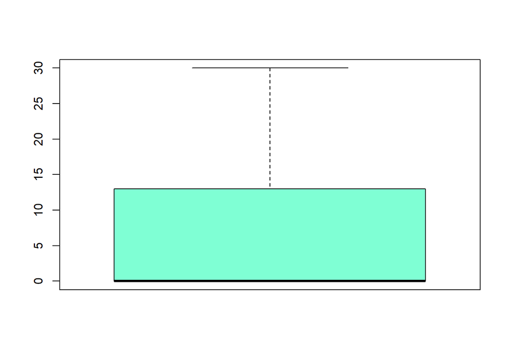

```r
boxplot(data$PhysHlth, col="#7FFFD4", varwidth=T)
```

There are no outliers for this variable. Let’s see for BMI:

```r
library(ggplot2)
boxplot.stats(data$BMI)
```

```
## $stats
## [1] 14 25 29 33 45
##
## $n
## [1] 1278
##
## $conf
## [1] 28.64642 29.35358
##
## $out
##  [1] 47 55 49 55 47 46 53 57 48 47 49 47 50 59 50 48 52 46 55 46 47 79 79 73 64
## [26] 67 66 67 64 66 67 46 54 49 46 53 50 48 49 49 57
```

[figure not shown]

```r
ggplot() + aes(x=data$BMI)+geom_boxplot(size=0.2, outlier.color = "red", color="black",fill="azure1")+
  labs(fill= "bmi")+theme(text=element_text(size=0.6))
```

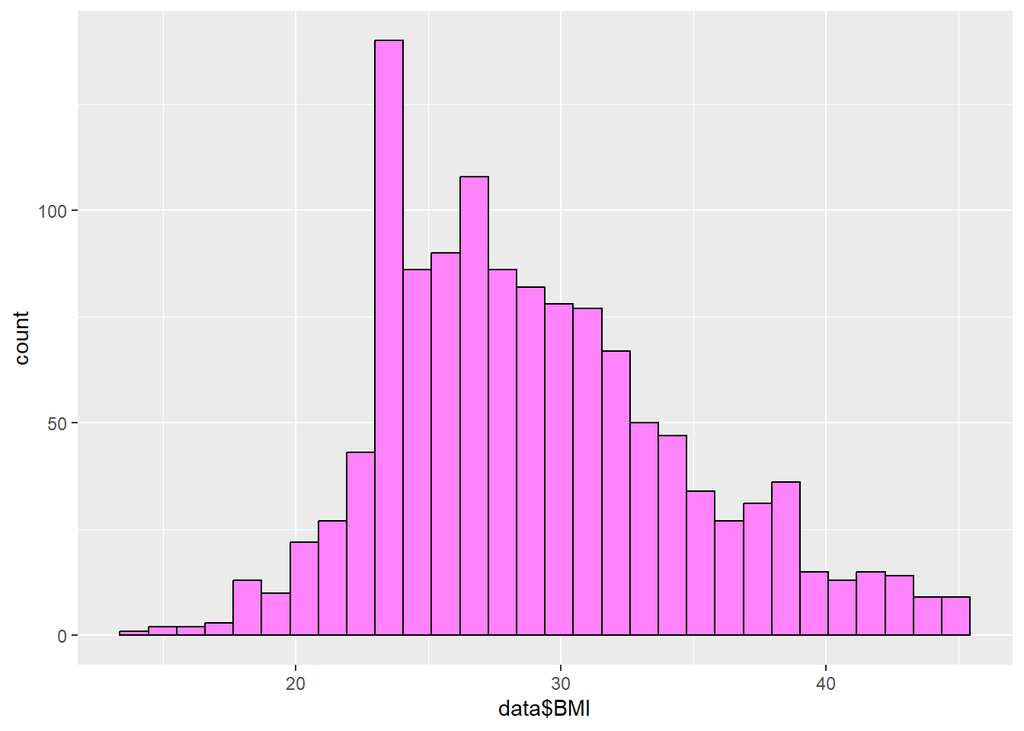

```r
#we observe that all values exceeding the number 45 are outliers
#we can see it also using the IQR METHOD
QI <- quantile(data$BMI, 0.25)
QS <- quantile(data$BMI, 0.75)
IQR = QS-QI
outliers = sum(data$BMI < QI - 1.5*IQR | data$BMI > QS + 1.5*IQR)
#we remove 41 outliers
data = data[data$BMI<=45,]

 ggplot() + aes(data$BMI)+
geom_histogram(color="black",fill="orchid1", bins=30)
```

We continue with Mental Health variable.

```r
summary(data$MentHlth)
```

```
##    Min. 1st Qu.  Median    Mean 3rd Qu.    Max.
##   0.000   0.000   0.000   4.503   4.000  30.000
```

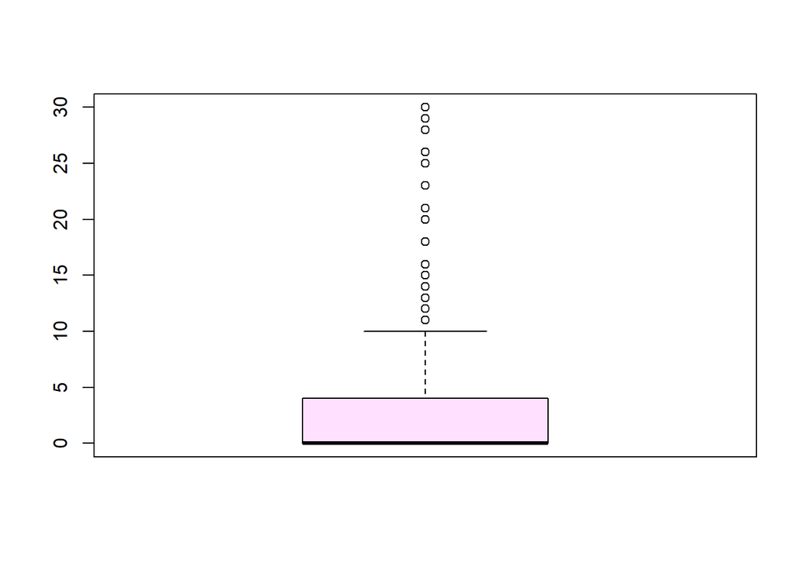

```r
boxplot(data$MentHlth, col = "#FFE1FF")
```

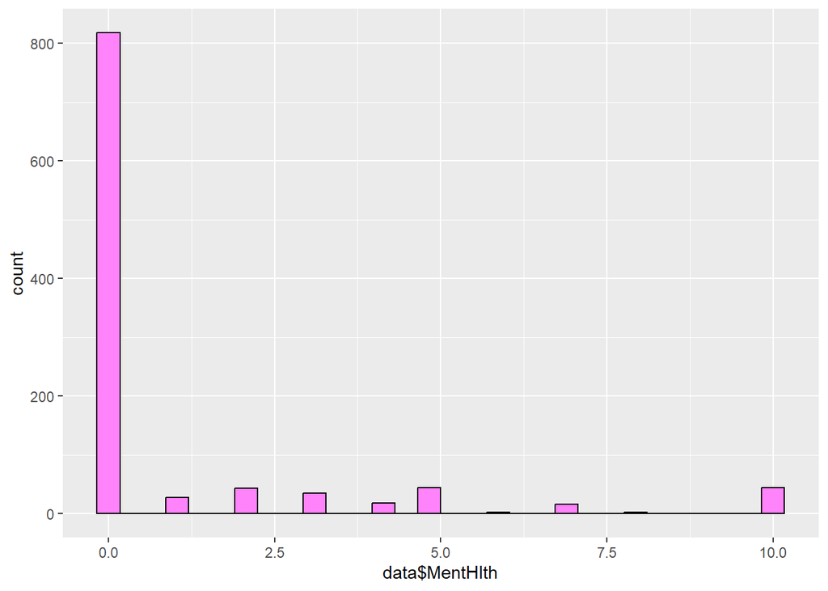

```r
#keep values lower or equal to 10
data=data[data$MentHlth<=10,]
 ggplot() + aes(data$MentHlth)+
geom_histogram(color="black",fill="orchid1", bins=30)
```

We observe the majority of the observations have any day where their mental health was not good during the past 30 days (including stress, depression, and problems with emotions). We have only removed the values exceeding 10 bad days. But again, these outliers will be included for FA (III) and Clustering (IV).

The following variables are scaled. We have also computed all the different analysis (II, III, IV) making fewer groups for each variable in order to reduce the noise. However, the results were the similar. Therefore, we prefer to keep the data as it was and store as much information as possible.

thirteen-level AGE category - 1: Age 18 to 24 • 2 Age 25 to 29 • 3 Age 30 to 34 • 4 Age 35 to 39 • 5 Age 40 to 44 • 6 Age 45 to 49 • 7 Age 50 to 54 • 8 Age 55 to 59 • 9 Age 60 to 64 • 10 Age 65 to 69 • 11 Age 70 to 74 • 12 Age 75 to 79 • 13 Age 80 or older

EDUCATION-What is the highest grade or year of school you completed? • 1 Never attended school or only kindergarten • 2 Grades 1 through 8 (Elementary) • 3 Grades 9 through 11 (Some high school) • 4 Grade 12 or GED (High school graduate) • 5 College 1 year to 3 years (Some college or technical school) • 6 College 4 years or more (College graduate)

INCOME variable->Is your annual household income from all sources • 1: Less than $10,000 • 2 Less than $15,000 ($10,000 to less than $15,000) • 3 Less than $20,000 ($15,000 to less than $20,000) • 4 Less than $25,000 ($20,000 to less than $25,000) • 5 Less than $35,000 ($25,000 to less than $35,000) • 6 Less than $50,000 ($35,000 to less than $50,000) • 7 Less than $75,000 ($50,000 to less than $55,000) • 8 more than $75,000

## II) PCA

```r
# we need numerical variables for PCA
data$Income = as.numeric(data$Income)
data$Diabetes_012 = as.numeric(data$Diabetes_012)
data$BMI = as.numeric(data$BMI)
data$Age = as.numeric(data$Age)
data$PhysHlth= as.numeric(data$PhysHlth)
df = subset(data, select=c(BMI, Income, PhysHlth, Age))
resultspcsa = prcomp(df, scale=T)
summary(resultspcsa)
```

```
## Importance of components:
##                           PC1    PC2    PC3    PC4
## Standard deviation     1.2287 1.0379 0.8558 0.8249
## Proportion of Variance 0.3775 0.2693 0.1831 0.1701
## Cumulative Proportion  0.3775 0.6468 0.8299 1.0000
```

```r
#we create a matrix with results of our pca
df1 = df
xx=resultspcsa$x
xx= as.data.frame(xx)
df1$PC1 = xx$PC1
df1$PC2 = xx$PC2
df1$PC3 = xx$PC3
df1$PC4 = xx$PC4
#df1$PC5 = xx$PC5
# we want to observe the correlation between pca obtained
cor(df1)
```

```
##                   BMI      Income   PhysHlth         Age           PC1
## BMI       1.000000000 -0.09352889  0.1064749 -0.09209821  1.881254e-01
## Income   -0.093528886  1.00000000 -0.3189907 -0.21801609 -7.541256e-01
## PhysHlth  0.106474915 -0.31899067  1.0000000  0.20478560  7.476645e-01
## Age      -0.092098212 -0.21801609  0.2047856  1.00000000  5.888295e-01
## PC1       0.188125413 -0.75412557  0.7476645  0.58882951  1.000000e+00
## PC2      -0.882596001  0.07326712 -0.1197235  0.52783423  7.198098e-16
## PC3       0.430822548  0.26921217 -0.3179755  0.61089009 -4.655087e-17
## PC4      -0.005005921  0.59451776  0.5705749  0.03852427  1.214153e-15
##                    PC2           PC3           PC4
## BMI      -8.825960e-01  4.308225e-01 -5.005921e-03
## Income    7.326712e-02  2.692122e-01  5.945178e-01
## PhysHlth -1.197235e-01 -3.179755e-01  5.705749e-01
## Age       5.278342e-01  6.108901e-01  3.852427e-02
## PC1       7.198098e-16 -4.655087e-17  1.214153e-15
## PC2       1.000000e+00  1.347356e-15 -2.540581e-16
## PC3       1.347356e-15  1.000000e+00 -6.648757e-16
## PC4      -2.540581e-16 -6.648757e-16  1.000000e+00
```

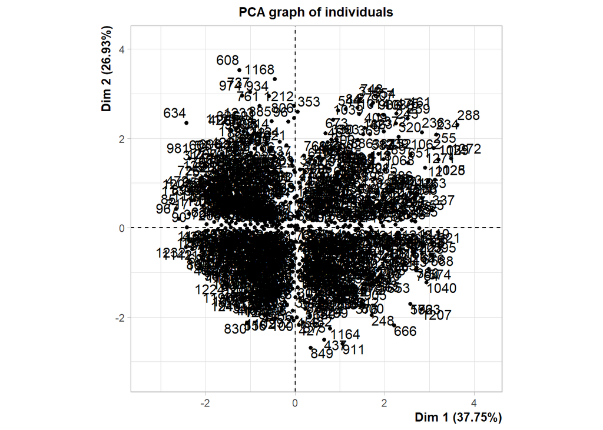

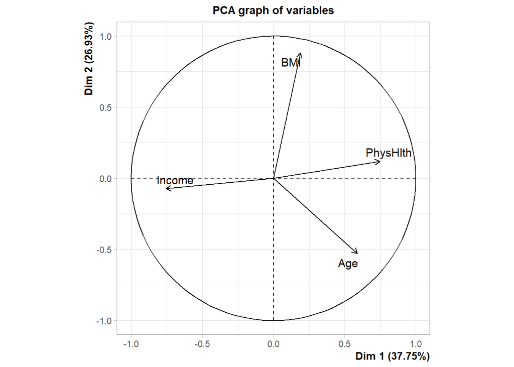

```r
pca2 <- PCA(df, scale.unit = T, ncp = 4, graph = TRUE)
```

```r
print(pca2)
```

```
## **Results for the Principal Component Analysis (PCA)**
## The analysis was performed on 1052 individuals, described by 4 variables
## *The results are available in the following objects:
##
##    name               description
## 1  "$eig"             "eigenvalues"
## 2  "$var"             "results for the variables"
## 3  "$var$coord"       "coord. for the variables"
## 4  "$var$cor"         "correlations variables - dimensions"
## 5  "$var$cos2"        "cos2 for the variables"
## 6  "$var$contrib"     "contributions of the variables"
## 7  "$ind"             "results for the individuals"
## 8  "$ind$coord"       "coord. for the individuals"
## 9  "$ind$cos2"        "cos2 for the individuals"
## 10 "$ind$contrib"     "contributions of the individuals"
## 11 "$call"            "summary statistics"
## 12 "$call$centre"     "mean of the variables"
## 13 "$call$ecart.type" "standard error of the variables"
## 14 "$call$row.w"      "weights for the individuals"
## 15 "$call$col.w"      "weights for the variables"
```

```r
head(pca2$eig)
```

```
##        eigenvalue percentage of variance cumulative percentage of variance
## comp 1  1.5098189               37.74547                          37.74547
## comp 2  1.0772865               26.93216                          64.67763
## comp 3  0.7323784               18.30946                          82.98709
## comp 4  0.6805162               17.01291                         100.00000
```

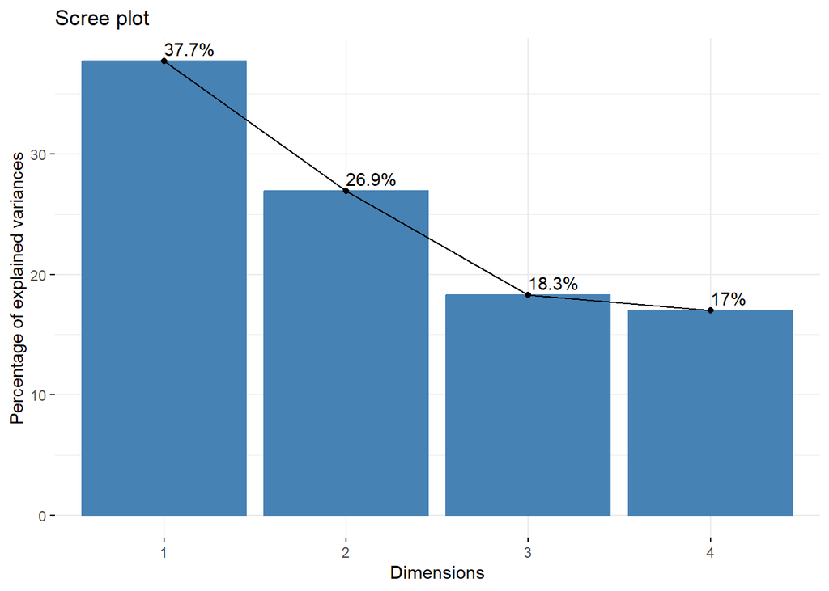

```r
# scree plot:
fviz_screeplot(pca2, addlabels = TRUE)
```

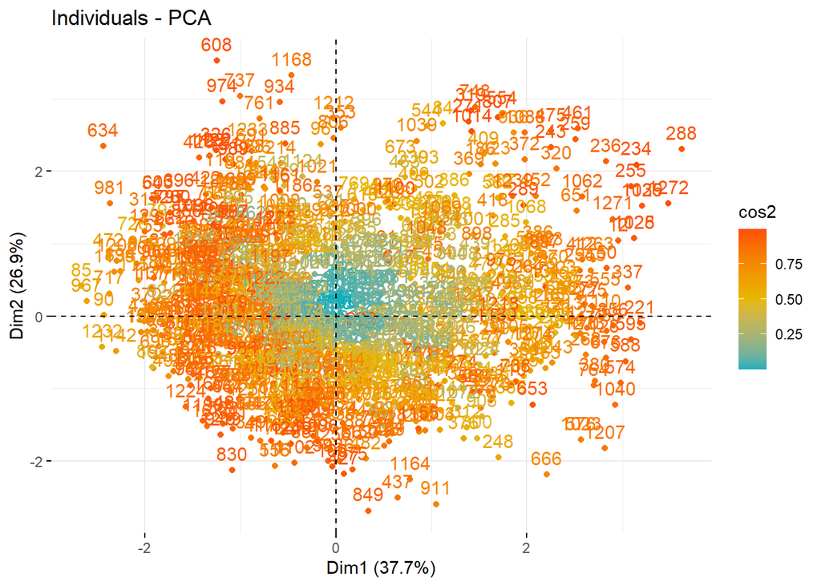

```r
#Representation of the observations for princ. comp.
fviz_pca_ind(pca2,
             col.ind = "cos2", # Color by the quality of representation
             gradient.cols = c("#00AFBB", "#E7B800", "#FC4E07"),
             repel = FALSE)    # Avoid text overlapping
```

With the following graph we can see how is the contribution of the variables and principal components.

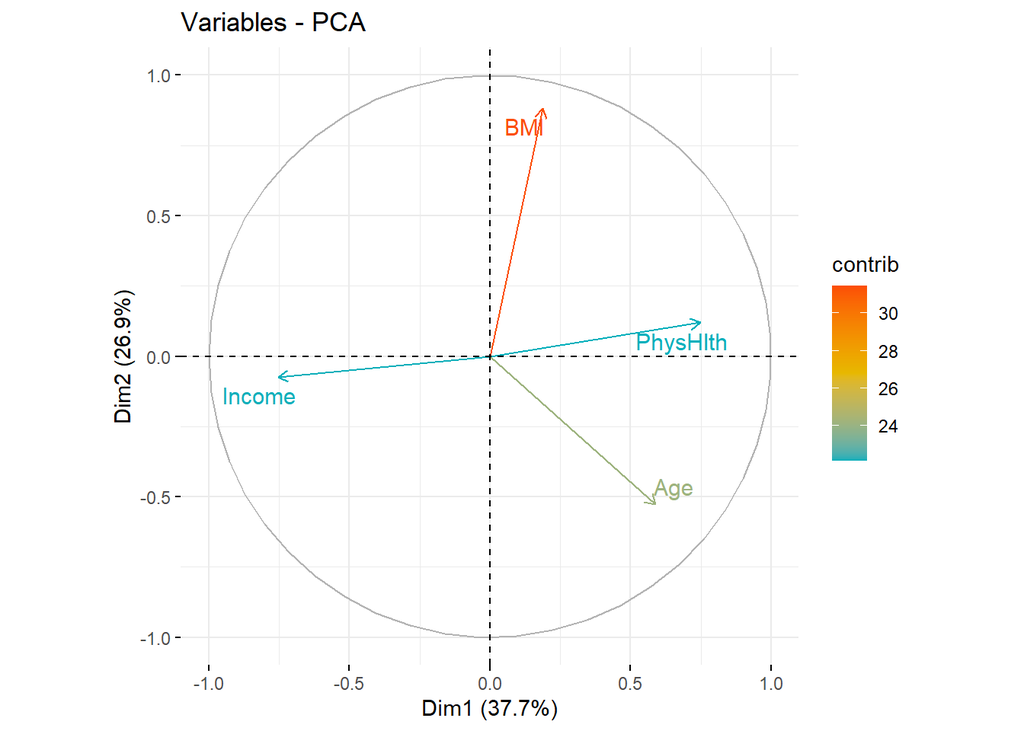

```r
#Representation of variables and principal components:
fviz_pca_var(pca2,
             col.var = "contrib", # Color by contributions to the PCA
             gradient.cols = c("#00AFBB", "#E7B800", "#FC4E07"),
             repel = TRUE)# TO avoid text overlapping
```

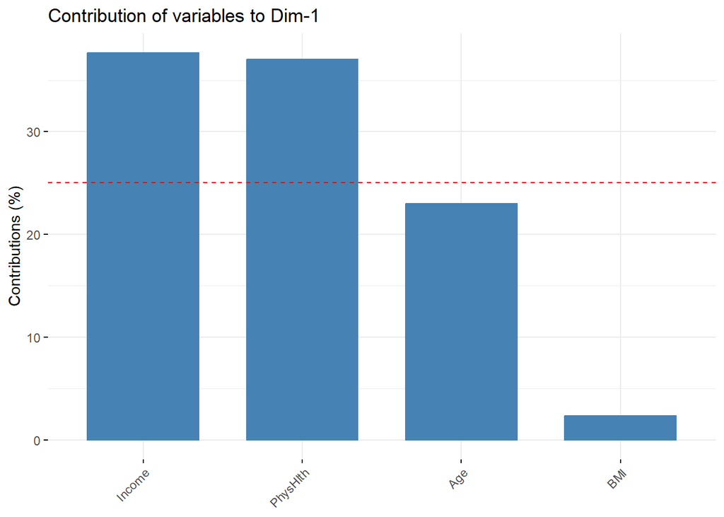

```r
fviz_contrib(pca2, choice = "var", axes = 1)
```

We can see Income and Physical Health are the variables that contribute the most to dimension 1. Remember, Physical Health is how many days during the past 30 days was their physical health not good.

Now, we use bigplot in order to visualize variables and individuals, and we select the 40 first observations that contributed the most

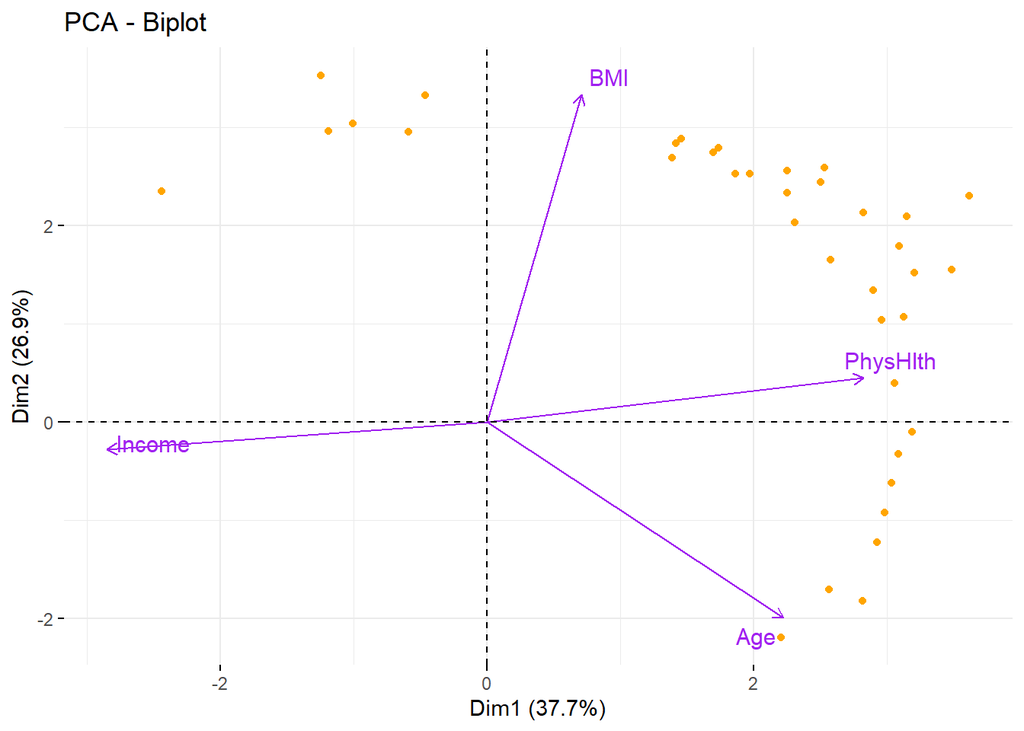

```r
fviz_pca_biplot(pca2, repel = TRUE,
                geom= "point",
                col.var = "purple", # Variables color
                col.ind = "orange", # Individuals color
                select.ind = list(contrib = 40))
```

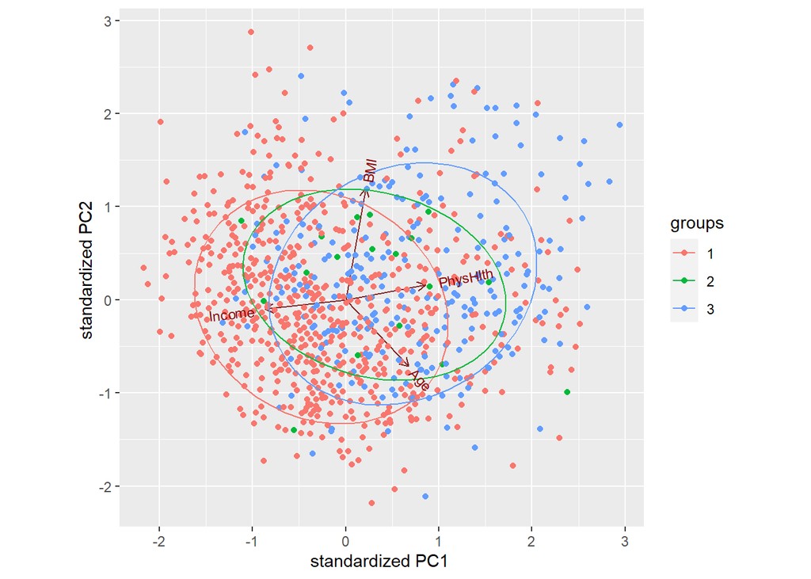

```r
#we create a new object to see whether they have diabetes or not
group = as.factor(data$Diabetes_012)
library(ggbiplot)
ggbiplot(pca2, ellipse=T, groups=group)
```

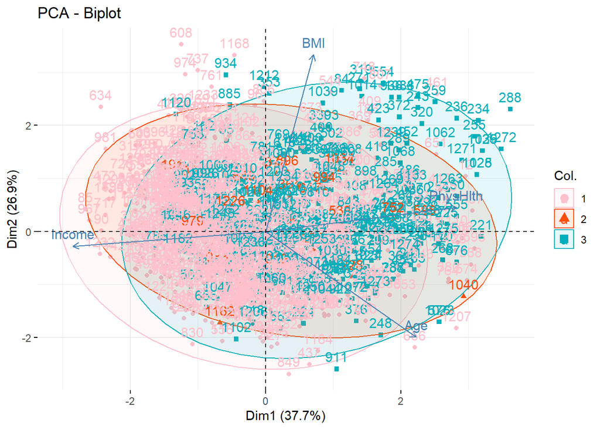

```r
fviz_pca_biplot(pca2, col.ind=group,
                palette = c("pink","#FC4E07","#00AFBB"),addEllipses = T,lengend.title="Diabetes",repel=F)
```

PCA was better for 1 and 2, therefore the others are not represented in the last bigplot.

We know with PCA we are not studying whether some variables contribute to a single one that in this case could be diabetes. Since it is an unsupervised tool, we want to reduce the dimensionality of our data set to see the how some variables could be related forming one group. We remarked Income and Physical health could be a subset contributing to one group and the same for Age and BMI for another. By observing the 3 circles in the graph where PC1 and PC2 are standardised, we can notice that those that are in the left hand side and marked with red haven’t diabetes. On the contrary, in blue and on in the right hand side, we see those individuals having diabetes. So, the distribution of diabetes depending on PC1 or PC2 is a little bit different. (but we cannot conclude Income is linked to not having diabetes).

## III) Factor analysis

We remove everything and replace missing values again. This time, we keep the “outliers”.

```r
rm(list=ls())
data = read.csv("diabetes.csv")
summary(data)
```

```
##   Diabetes_012        HighBP          HighChol        CholCheck
##  Min.   :0.0000   Min.   :0.0000   Min.   :0.0000   Min.   :0.0000
##  1st Qu.:0.0000   1st Qu.:0.0000   1st Qu.:0.0000   1st Qu.:1.0000
##  Median :0.0000   Median :1.0000   Median :1.0000   Median :1.0000
##  Mean   :0.6455   Mean   :0.6275   Mean   :0.5516   Mean   :0.9804
##  3rd Qu.:2.0000   3rd Qu.:1.0000   3rd Qu.:1.0000   3rd Qu.:1.0000
##  Max.   :2.0000   Max.   :1.0000   Max.   :1.0000   Max.   :1.0000
##
##       BMI            Smoker           Stroke        HeartDiseaseorAttack
##  Min.   :14.00   Min.   :0.0000   Min.   :0.00000   Min.   :0.0000
##  1st Qu.:25.00   1st Qu.:0.0000   1st Qu.:0.00000   1st Qu.:0.0000
##  Median :29.00   Median :0.0000   Median :0.00000   Median :0.0000
##  Mean   :29.91   Mean   :0.4781   Mean   :0.08764   Mean   :0.2496
##  3rd Qu.:33.00   3rd Qu.:1.0000   3rd Qu.:0.00000   3rd Qu.:0.0000
##  Max.   :79.00   Max.   :1.0000   Max.   :1.00000   Max.   :1.0000
##  NA's   :8
##   PhysActivity        Fruits          Veggies       HvyAlcoholConsump
##  Min.   :0.0000   Min.   :0.0000   Min.   :0.0000   Min.   :0.0000
##  1st Qu.:0.0000   1st Qu.:0.0000   1st Qu.:0.0000   1st Qu.:0.0000
##  Median :1.0000   Median :1.0000   Median :1.0000   Median :0.0000
##  Mean   :0.6111   Mean   :0.5501   Mean   :0.7089   Mean   :0.0313
##  3rd Qu.:1.0000   3rd Qu.:1.0000   3rd Qu.:1.0000   3rd Qu.:0.0000
##  Max.   :1.0000   Max.   :1.0000   Max.   :1.0000   Max.   :1.0000
##
##  AnyHealthcare     NoDocbcCost        GenHlth         MentHlth
##  Min.   :0.0000   Min.   :0.0000   Min.   :1.000   Min.   : 0.000
##  1st Qu.:1.0000   1st Qu.:0.0000   1st Qu.:2.000   1st Qu.: 0.000
##  Median :1.0000   Median :0.0000   Median :3.000   Median : 0.000
##  Mean   :0.9554   Mean   :0.1228   Mean   :3.043   Mean   : 4.669
##  3rd Qu.:1.0000   3rd Qu.:0.0000   3rd Qu.:4.000   3rd Qu.: 4.000
##  Max.   :1.0000   Max.   :1.0000   Max.   :5.000   Max.   :30.000
##                                                    NA's   :1
##     PhysHlth         DiffWalk           Sex              Age
##  Min.   : 0.000   Min.   :0.0000   Min.   :0.0000   Min.   : 1.00
##  1st Qu.: 0.000   1st Qu.:0.0000   1st Qu.:0.0000   1st Qu.: 8.00
##  Median : 0.000   Median :0.0000   Median :0.0000   Median : 9.50
##  Mean   : 7.543   Mean   :0.3552   Mean   :0.3619   Mean   : 9.16
##  3rd Qu.:12.750   3rd Qu.:1.0000   3rd Qu.:1.0000   3rd Qu.:11.00
##  Max.   :30.000   Max.   :1.0000   Max.   :1.0000   Max.   :13.00
##                                    NA's   :4
##    Education         Income
##  Min.   :1.000   Min.   :1.000
##  1st Qu.:4.000   1st Qu.:3.000
##  Median :5.000   Median :5.000
##  Mean   :4.689   Mean   :5.076
##  3rd Qu.:6.000   3rd Qu.:7.000
##  Max.   :6.000   Max.   :8.000
##
```

```r
anyNA(data)
```

```
## [1] TRUE
```

```r
# replace some NAs:
mean(data$BMI, na.rm = TRUE)
```

```
## [1] 29.91417
```

```r
data$BMI[is.na(data$BMI)]=mean(data$BMI,na.rm=TRUE)
mean(data$MentHlth, na.rm = TRUE)
```

```
## [1] 4.668755
```

```r
data$MentHlth[is.na(data$MentHlth)]=mean(data$MentHlth,na.rm=TRUE)
data$Sex[is.na(data$Sex)]= 0

anyNA(data)
```

```
## [1] FALSE
```

Since we want numeric data to do the factor analysis, we are going to create 2 new columns to replace those variables that are 0 or 1. Although we know these variables will be interpreted as numeric, we want to reduce the time and space required to process the data as well as increasing the precision (see bibliography, investigation of M. Usman Ali and collaborators)

The first variable is going to be the sum of bad habits or bad things that have occurred to the individual: - high blood pressure: 1 means the person has high blood pressure - high cholesterol - smoke: The person smoked at least 100 cigarettes in his entire life [5 packs = 100 cigarettes] 0 = no, 1 = yes - stroke: 1 means he had a stroke - heart disease attack - heavy alcohol consumption: Heavy drinkers (adult men having more than 14 drinks per week and adult women having more than 7 drinks per week) 0 = no 1 = yes - No doctor cost: it means there was a time in the past 12 months where he needed to see a doctor but could not afford it - DiffWalk: serious difficulty walking or climbing stairs (1=yes,0=no)

Then we remove the variables that have been replaced.

```r
data$Badthings =rowSums(data [,c(2,3,6,7,8,12,14,18)])
data$HighBP=NULL
data$HighChol= NULL
data$Smoker=NULL
data$Stroke=NULL
data$HeartDiseaseorAttack=NULL
data$HvyAlcoholConsump=NULL
data$NoDocbcCost=NULL
data$DiffWalk=NULL
```

The second new variable is going to be the sum of good things: - Cholcheck: 0 = no cholesterol check in 5 years and 1=yes. So we sum if there is at least 1 check - physActivity:physical activity in past 30 days - not including job 0 = no 1 = yes - fruits: Consume Fruit 1 or more times per day 0 = no 1 = yes - veggies: Consume Vegetables 1 or more times per day 0 = no 1 = yes - any health care: Have any kind of health care coverage, including health insurance, prepaid plans such as HMO

```r
#notice now the columns correspond to differente numers because we have removed some variables
data$Goodthings =  rowSums(data [, c (2,4,5,6,7)])
data$CholCheck= NULL
data$PhysActivity=NULL
data$Fruits=NULL
data$Veggies=NULL
data$AnyHealthcare=NULL
# we are going to remove also sex var. since the results are better when it is not included
data$Sex=NULL
```

Now, we want to see if there exist correlation between the variables before starting our factor analysis. We are also going to plot a sedimentation graph that shows us the number of the principal component vs its corresponding value.

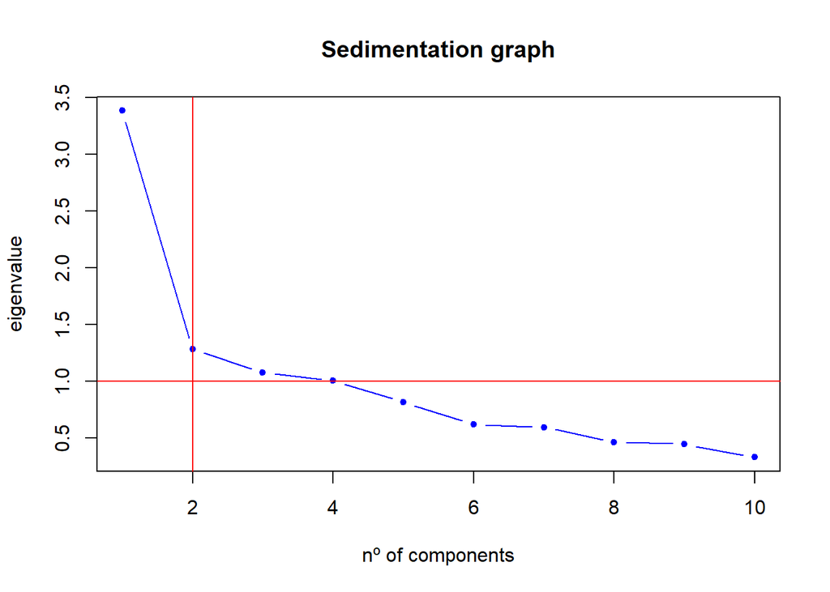

```r
R = cor(data[,1:10])
#R

e=eigen(R)$val
plot(e, type="b", pch=20, col="blue", main="Sedimentation graph", xlab="nº of components",ylab="eigenvalue")
abline(h=1, v=2, col="red")
```

We observe that with the second factor the slope changes drastically. the work of Kristopher J. Preacher &Robert C. MacCallum suggest us that we should choose the number of factors for which eigen value is greater than 1. (check bibliography). Therefore, we are going to select 4 factors and see what happens.

```r
library(psych)
facto=principal(data,nfactors=4, rotate="none")
cbind(facto$loadings, facto$uniquenesses)
```

```
##                     PC1         PC2         PC3          PC4
## Diabetes_012  0.5874671 -0.14998203  0.36377963 -0.339467671 0.3848138
## BMI           0.3314887  0.41626514  0.08906825 -0.675532211 0.2525617
## GenHlth       0.8195751  0.03736016  0.09705023  0.106548064 0.3061297
## MentHlth      0.4436143  0.54215714 -0.02334652  0.483914592 0.2745536
## PhysHlth      0.7373317  0.15390130  0.18062838  0.310236841 0.3037828
## Age           0.2760738 -0.77626042  0.28096292  0.064881842 0.2380532
## Education    -0.4611939  0.31580146  0.69743710  0.082607482 0.1943272
## Income       -0.6653446  0.15699258  0.42188107 -0.056973560 0.3514402
## Badthings     0.7597615 -0.07009157  0.27017673  0.000640118 0.3448538
## Goodthings   -0.4546772 -0.18293374  0.27730924  0.276224939 0.6066032
```

#Interpretation

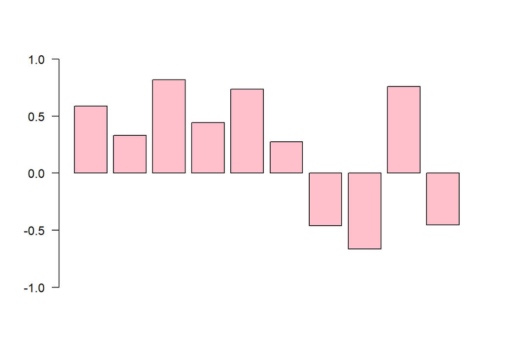

```r
par(mfrow=c(1,1))
barplot(facto$loadings[,1], names=F, las=2, col="pink", ylim = c(-1, 1))
```

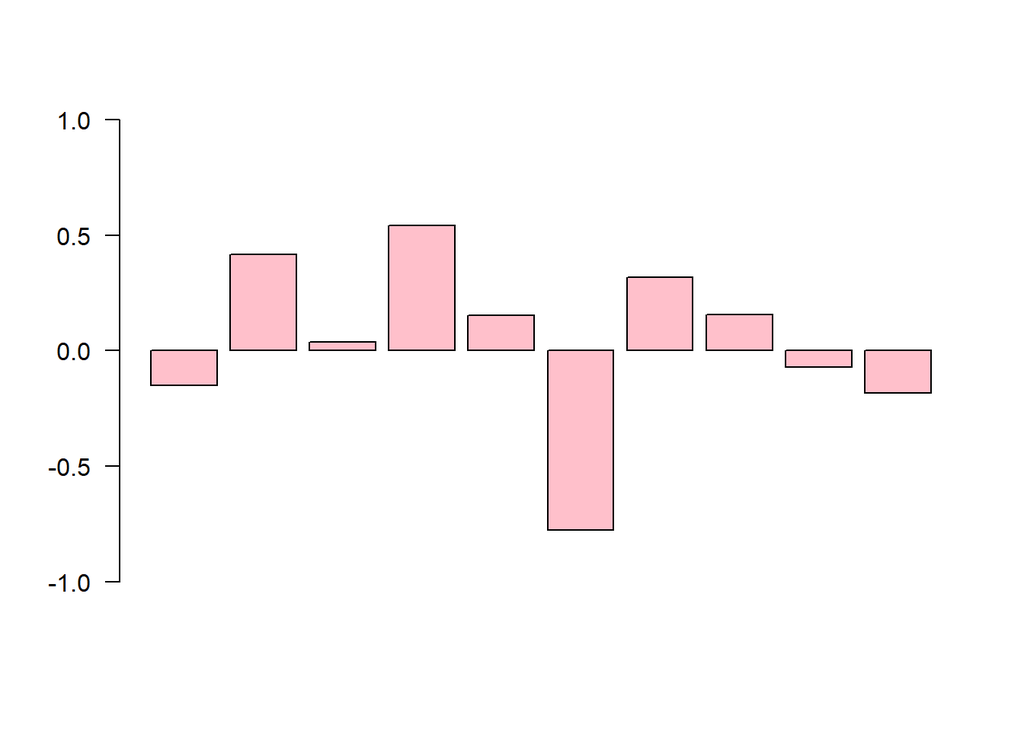

```r
barplot(facto$loadings[,2], names=F, las=2, col="pink", ylim = c(-1, 1))
```

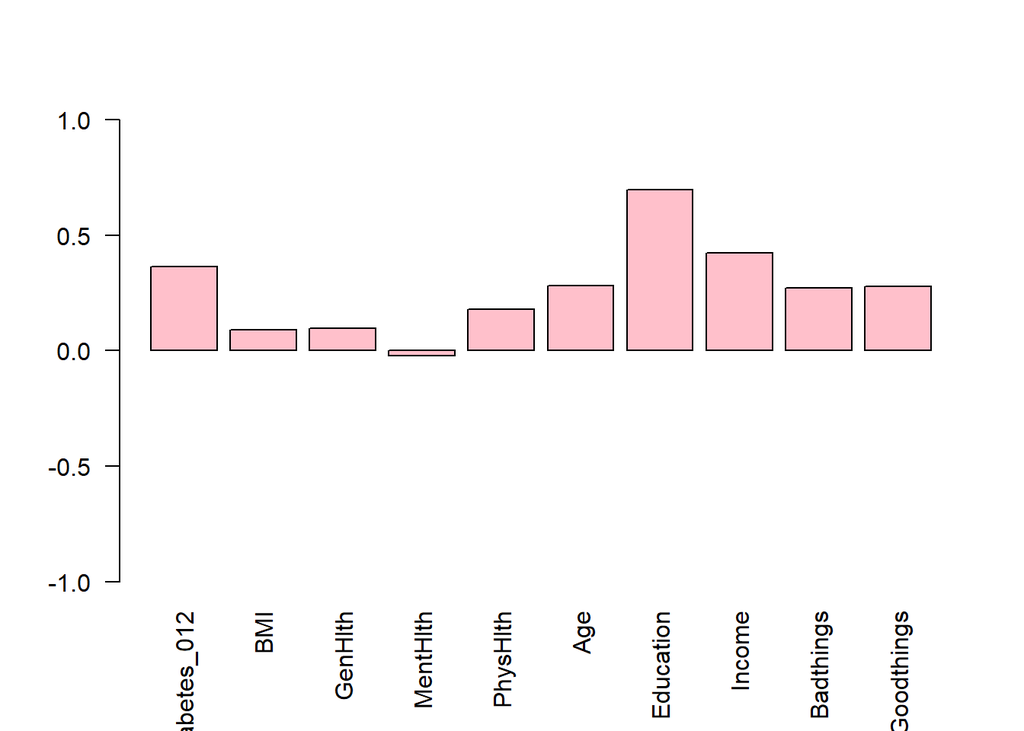

```r
barplot(facto$loadings[,3], las=2, col="pink", ylim = c(-1, 1))
```

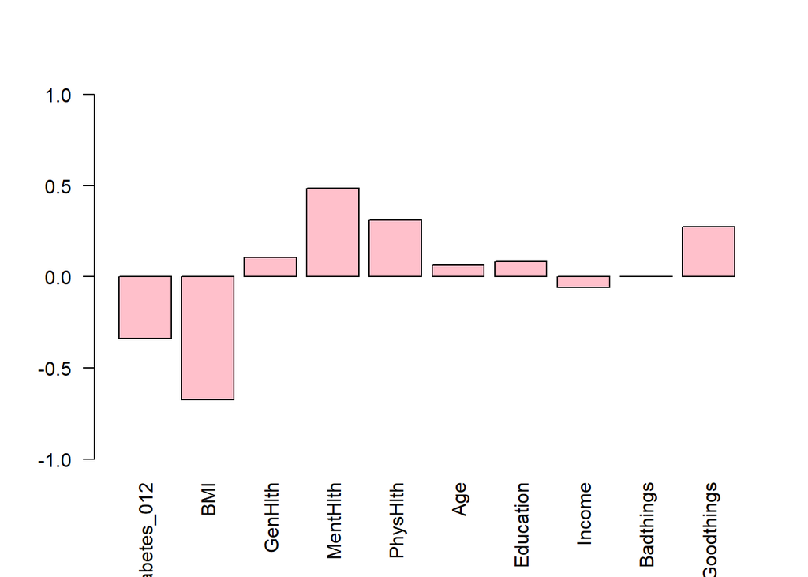

```r
barplot(facto$loadings[,4], las=2, col="pink", ylim = c(-1, 1))
```